# Topic 6 Exercises: Selecting Model Terms

# Theory Questions

6.8.1

1. Which of the three models with K predicts has the smallest training RSS?

The model with K predictors is the model with the smallest RSS among all the possible models with K predictors. When doing stepwise selection, the model with K predictors is the model with the smallest RSS among the P - K models. When performing backward stepwise selection, the model with K predictors in the model with the smallest RSS among the K models which contains all but one of the predictors. So, the model with K predictors has the smallest training RSS is the one obtained from the best subset selection as it is the one selected among all K predictors models.

2. Which of the three models with K predictors has the smallest test RSS?

It depends. The best subset selection may have the smallest test RSS because it takes into accountmore models than the other methods, but other methods might also picka a model with the smallest test RSS by chance.

4. The predictors in the K-variable model identified by forward stepwise are a subset of the predictors in the (K+1) - variable model identified by forward stepwise selection

This is true. The model with (K+1) predictors is obtained by adding the predictors in the model with K predictors with one more predictor.

2. The predictors in the K-Variable model identified by backward stepwise are a subset of the predictors in the (K+1) - variable model identified by backward stepwise slection.

Also true. The model with K predictors is otained by removing one predictor from the model with (K+1) predictors

3. The predictors in the k-variable model identified by backward stepwise are a subset of the predictors in (K+1)-variable model identified by forward stepwse selection.

Ths is false…There is no connection between the models obtained from the methods of forward selection and backward selection.

4. The predictors in the K-variable model identified by forward stepwise are a subset of the predictors in the (K+1)-variable model identified by backward stepwise selection.

This is also false for the same reason as iii.

22. The predictors in the K-variable model identified by the best subset are a subset of the predictors in the (K+1)-variable model identified by best subset selection.

This is false too. The model with (K+1) predictors is obtained by selecting amongst all possible models with (K+1) predictors. Thus, it does not necessarily contain the predictors selected for the K-variable model.

6.8.2

1. The lasso, relative to least squares is:

Less flexible and will give better prediction accuracy when its increase in bias is less than its decrease in variance.

2. Ridge regression relative to least squares:

Similiar to lasso, ridge regression is also less flexible and will give improed prediction accuracy when its increase in bias is less than its decrease in variance.

3. Non-linear methods relative to least squares:

Non-linear methods are - by definition - are more flexible and will give improved prediction accuracy when their increase in variance are less than their decrease in bias.

# Programming Exercises

6.8.9

```r
library(ISLR)
data(College)
set.seed(11)
train = sample(1:dim(College)[1], dim(College)[1]/2)
test <- -train
College_training <- College[train, ]
College_testing <- College[test, ]
```

```r
fitting_lm <- lm(Apps ~., data = College_training)
testing_lm <- predict(fitting_lm, College_testing)
mean((testing_lm - College_testing$Apps)^2)
```

```
## [1] 1538442
```

```r
#install.packages("glmnet")
library(glmnet)
training_matrix <- model.matrix(Apps ~ ., data = College_training)
testing_matrix <- model.matrix(Apps ~ ., data = College_testing)
grid <- 10^seq(4, -2, length = 100)
fit_ridge <- glmnet(training_matrix, College_training$Apps, alpha = 0, lambda = grid, thresh = 1e-12)
cv_ridge <- cv.glmnet(training_matrix, College_training$Apps, alpha= 0, lambda = grid, thresh = 1e-12)
best_lambda <- cv_ridge$lambda.min
best_lambda
```

```
## [1] 18.73817
```

```r
ridge_test <- predict(fit_ridge, s = best_lambda, newx = testing_matrix)
mean((ridge_test - College_testing$Apps)^2)
```

```
## [1] 1608859
```

As you can see, the testing mean-squared error is higher for ridge regression than for OLS.

```r
lasso_train <- glmnet(training_matrix, College_training$Apps, alpha = 1, lambda = grid, thresh = 1e-12)
lasso_cv <- cv.glmnet(training_matrix, College_training$Apps, alpha = 1, lambda = grid, thresh = 1e-12)
best_lamda_lasso <- lasso_cv$lambda.min
best_lamda_lasso
```

```
## [1] 21.54435
```

```r
test_lasso <- predict(lasso_train, s = best_lamda_lasso, newx = testing_matrix)
mean((test_lasso - College_testing$Apps)^2)
```

```
## [1] 1635280
```

The testing mean-squared error is also higher for ridge regression when compared to OLS’s MSE.

```r
predict(lasso_train, s = best_lamda_lasso, type = "coefficients")
```

```
## 19 x 1 sparse Matrix of class "dgCMatrix"
##                         1
## (Intercept) -836.50402310
## (Intercept)    .
## PrivateYes  -385.73749394
## Accept         1.17935134
## Enroll         .
## Top10perc     22.70211938
## Top25perc      .
## F.Undergrad    0.07062149
## P.Undergrad    0.01366763
## Outstate      -0.03424677
## Room.Board     0.01281659
## Books         -0.02167770
## Personal       .
## PhD           -1.46396964
## Terminal      -5.17281004
## S.F.Ratio      5.70969524
## perc.alumni   -9.95007567
## Expend         0.14852541
## Grad.Rate      5.79789861
```

```r
#install.packages("pls")
library(pls)
```

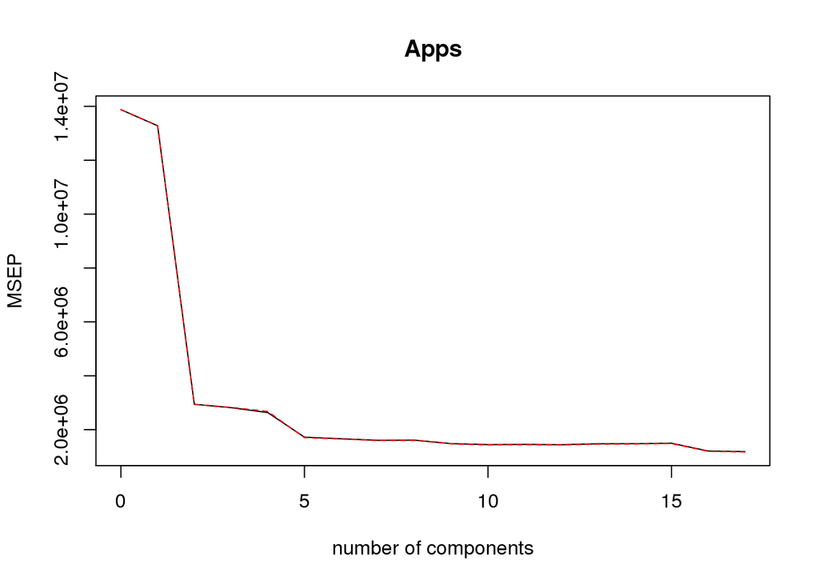

```r
pcr_fitting <- pcr(Apps ~ ., data = College_training, scale = TRUE, validation = "CV")
validationplot(pcr_fitting, val.type = "MSEP")
```

```r
pcr_testing <- predict(pcr_fitting, College_testing, ncomp = 10)
mean((pcr_testing - College_testing$Apps)^2)
```

```
## [1] 3014496
```

Again - the testing mean-squared error is also higher for PCR than for OLS!

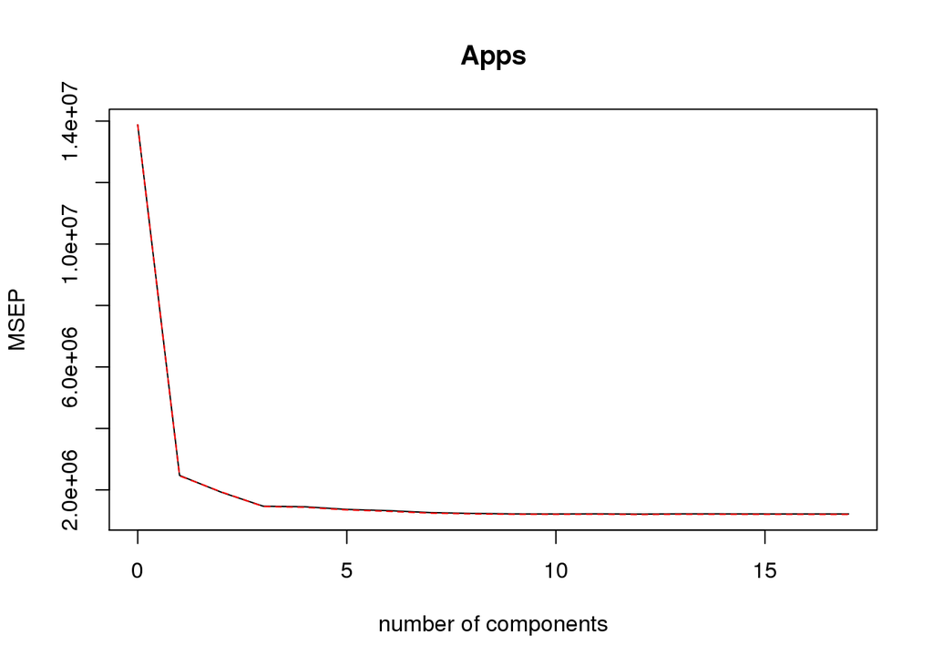

```r
pls_fitting <- plsr(Apps ~ ., data = College_training, scale = TRUE, validation = "CV")
validationplot(pls_fitting, val.type = "MSEP")
```

```r
pls_testing <- predict(pls_fitting, College_testing, ncomp = 10)
mean((pls_testing - College_testing$Apps)^2)
```

```
## [1] 1508987
```

In this case, the testing mean-squared error is lower for PLS than for OLS.

```r
testing_average <- mean(College_testing$Apps)
lm_r2 <- 1 - mean((testing_lm - College_testing$Apps)^2) / mean((testing_average - College_testing$Apps)^2)
ridge_r2 <- 1 - mean((ridge_test - College_testing$Apps)^2) / mean((testing_average - College_testing$Apps)^2)
lasso_r2 <- 1 - mean((test_lasso - College_testing$Apps)^2) / mean((testing_average - College_testing$Apps)^2)
pcr_r2 <- 1 - mean((pcr_testing - College_testing$Apps)^2) / mean((testing_average - College_testing$Apps)^2)
pls_r2 <- 1 - mean((pls_testing - College_testing$Apps)^2) / mean((testing_average - College_testing$Apps)^2)
```

```r
lm_r2
```

```
## [1] 0.9044281
```

```r
ridge_r2
```

```
## [1] 0.9000536
```

```r
lasso_r2
```

```
## [1] 0.8984123
```

```r
pcr_r2
```

```
## [1] 0.8127319
```

```r
pls_r2
```

```
## [1] 0.9062579
```

The test R^2 for each model is close to .9 for all models except pcr. With this information, we can conclude that all the models used except pcr predict college applications with a high degree of accuracy.